# Blackwell - Brand Preference

## 3.2 Without extreme values

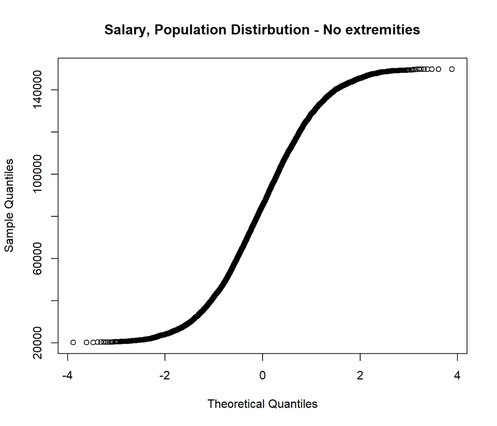

```r
q2 <- qqnorm(new$salary, main = "Salary, Population Distirbution - No extremities")
```

# 4 **Data exploration**

## 4.1 Salary and Brand choice

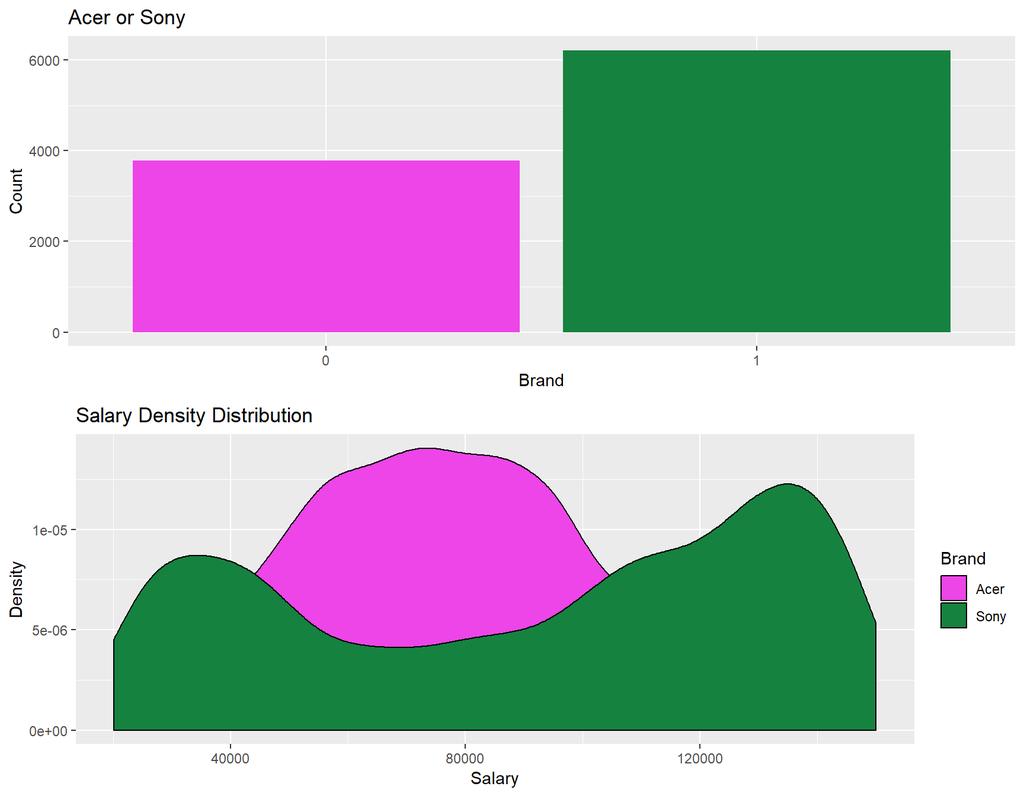

```r
library(ggplot2)
library(dplyr)
library(gridExtra)


l <- data %>% group_by(brand, salary, credit, age, elevel, zipcode, car) %>% tally() #sony is almost doubly preferred

l2 <- ggplot(l, aes(brand, fill = brand)) +
  geom_bar() +
  labs(title = "Acer or Sony", x = "Brand", y = "Count")

l2 <- l2 + scale_fill_manual(values=c("#ED45E8", "#16823F")) + guides(fill = FALSE)

l1 <- ggplot(new, aes(salary, fill = brand)) +
   geom_density(kernel = "gaussian") +
   labs(title = "Salary Density Distribution", x = "Salary", y = "Density") + scale_fill_discrete(name = "Brand", labels = c("Acer", "Sony"))

l1 <- l1 + scale_fill_manual(labels = c("Acer", "Sony"), values=c("#ED45E8", "#16823F")) + guides(fill = guide_legend("Brand"))

grid.arrange(l2, l1)
```

## 4.2 Credit and brand choice

To see if the variable **credit** showed any correlation or similar pattern as salary did similar graphics were plotted. Checking the density distribution of **credit** for each brand preference showed a costant distribution over time and similar for both brands. The scatter plot between *credit* and the main good-looking predictor so far *salary* showed that their relationship was all over the place with a slight downward trend as salary got bigger. Thus, credit does not seem to hold much predictive power with regards to our future predictions.

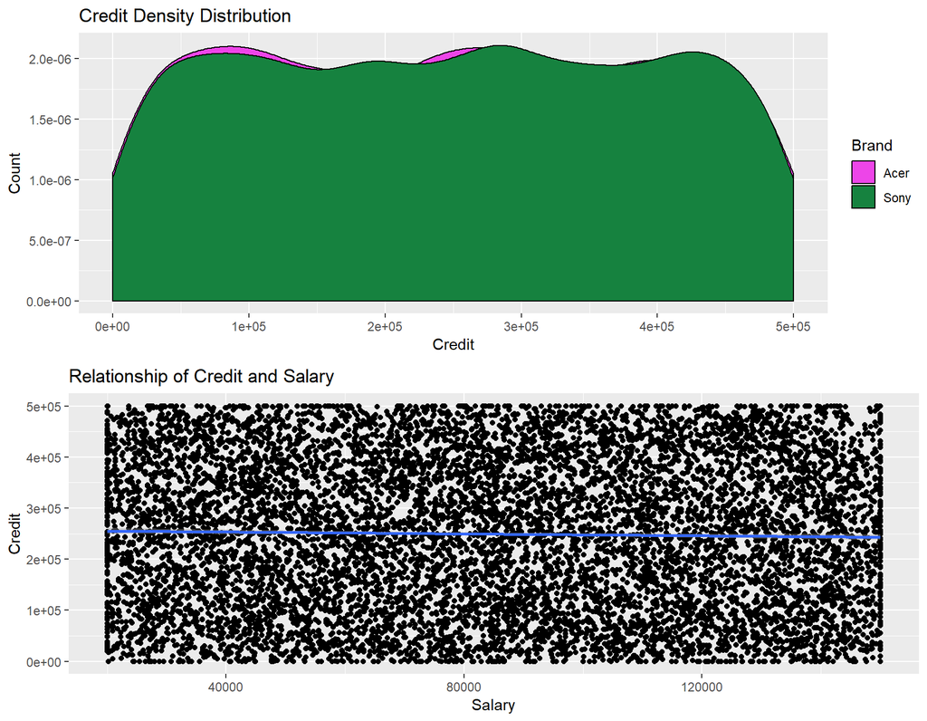

```r
l3 <- ggplot(l, aes(salary,credit)) +
  geom_point() + geom_smooth(method = "lm") +
  labs(title = "Relationship of Credit and Salary", x = "Salary", y = "Credit")

l4 <- ggplot(l, aes(credit, fill = brand)) +
    geom_density(kernel = "gaussian") +
    labs(title = "Credit Density Distribution", x = "Credit", y = "Count")


l4 <- l4 + scale_fill_manual(labels = c("Acer", "Sony"), values=c("#ED45E8", "#16823F")) + guides(fill = guide_legend(title = "Brand"))

grid.arrange(l4, l3)
```

## 4.3 Education Level, Zipcode, Car, Age and Brand Choice

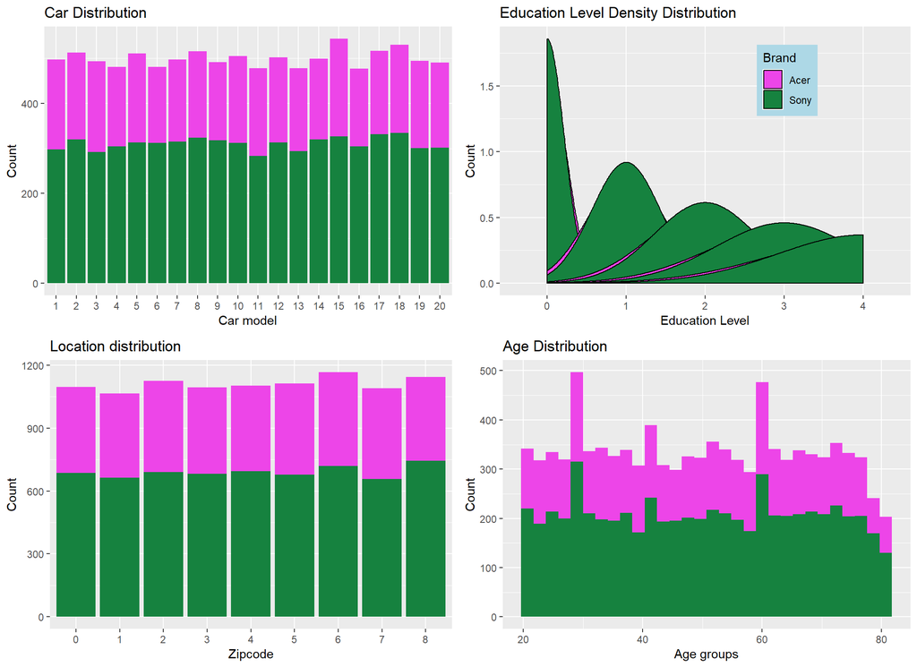

```r
e2 <- ggplot(l, aes(elevel, fill = brand)) +
       geom_density(kernel = "gaussian") +
       scale_fill_discrete(name = "Brand", labels = c("Acer", "Sony")) +
       labs(title = "Education Level Density Distribution", x = "Education Level", y = "Count")

e2 <- e2 + scale_fill_manual(labels = c("Acer", "Sony"),values=c("#ED45E8", "#16823F")) +
  guides(fill=guide_legend(title = "Brand")) +
  theme(legend.background = element_rect(fill="lightblue", size=0.5, linetype="solid"), legend.position = c(0.7, 0.8))

e3  <- ggplot(l, aes(zipcode, fill = brand)) +
            geom_histogram(stat = "count") +
            scale_fill_discrete(name = "Brand", labels = c("Acer", "Sony")) +
            labs(title = "Location distribution", x = "Zipcode", y = "Count")
e3 <- e3 + scale_fill_manual(values=c("#ED45E8", "#16823F")) + guides(fill = FALSE)

e1 <- ggplot(l, aes(car, fill = brand)) +
      geom_histogram(stat = "count") +
      scale_fill_discrete(name = "Brand", labels = c("Acer", "Sony")) +
      labs(title = "Car Distribution", x = "Car model", y = "Count")
e1 <- e1 + scale_fill_manual(values=c("#ED45E8", "#16823F")) + guides(fill=FALSE)

e4 <- ggplot(l, aes(age, fill = brand)) +
      geom_histogram() +
      scale_fill_discrete(name = "Brand", labels = c("Acer", "Sony")) +
      labs(title = "Age Distribution", x = "Age groups", y = "Count")

e4 <- e4 + scale_fill_manual(values=c("#ED45E8", "#16823F")) + guides(fill=FALSE)

grid.arrange(e1, e2, e3, e4)
```

As doubted, education does not seem to influence the brand choice even when checking for age and salary. Distributions are almost identical across education levels. As mentioned above people with mid-range salaries tend to prefer **Acer** and the rest **Sony**. Moreover, *zipcode*, *age* and *car* similar to *elevel* do not show any particular pattern that could help explaining brand choice.